# part2

2026-05-14

```r
suppressPackageStartupMessages({
  library(Seurat)
  library(Matrix)
  library(patchwork)
  library(dplyr)
  library(ggplot2)
  library(pheatmap)
  library(SingleCellExperiment)
  library(miloR)
  library(scater)
  library(scran)
})
options(Seurat.object.assay.version = "v3")
```

# Loading Seurat Obj (all 4 samples integrated together 2KO (MECOM-) and 2WT)

```r
seurat <- readRDS("seurat_int_all.rds")

#metadata
head(seurat@meta.data)
```

```
##                         orig.ident nCount_RNA nFeature_RNA        sample
## AAACCCAAGGCTCACC-1_7 SeuratProject       8901         2944 B1_17_1_day21
## AAACCCAAGTTGAATG-1_7 SeuratProject       5406         1951 B1_17_1_day21
## AAACCCATCAAATGAG-1_7 SeuratProject      20568         5011 B1_17_1_day21
## AAACCCATCGGAGTGA-1_7 SeuratProject       6836         2316 B1_17_1_day21
## AAACGAACAGAACTTC-1_7 SeuratProject      20081         5028 B1_17_1_day21
## AAACGAACAGAGTAAT-1_7 SeuratProject       4585         1661 B1_17_1_day21
##                      condition percent.mt     S.Score   G2M.Score Phase
## AAACCCAAGGCTCACC-1_7        KO   6.167846 -0.08050733 -0.16878495    G1
## AAACCCAAGTTGAATG-1_7        KO   5.142434 -0.12040966 -0.17716217    G1
## AAACCCATCAAATGAG-1_7        KO   5.532867 -0.09840637 -0.17737080    G1
## AAACCCATCGGAGTGA-1_7        KO   5.324751 -0.04187607 -0.14754462    G1
## AAACGAACAGAACTTC-1_7        KO   7.683880  0.13344656  0.56417048   G2M
## AAACGAACAGAGTAAT-1_7        KO   8.767721 -0.09604299 -0.09999307    G1
##                      integrated_snn_res.0.6 seurat_clusters
## AAACCCAAGGCTCACC-1_7                      4               3
## AAACCCAAGTTGAATG-1_7                      2               9
## AAACCCATCAAATGAG-1_7                      3               5
## AAACCCATCGGAGTGA-1_7                      0               4
## AAACGAACAGAACTTC-1_7                      1              10
## AAACGAACAGAGTAAT-1_7                      0               4
##                                  final_type
## AAACCCAAGGCTCACC-1_7      Contractile Mural
## AAACCCAAGTTGAATG-1_7      Mural Progenitors
## AAACCCATCAAATGAG-1_7        Epicardial-like
## AAACCCATCGGAGTGA-1_7  Fibroblast-like Mural
## AAACGAACAGAACTTC-1_7 Epicardial Progenitors
## AAACGAACAGAGTAAT-1_7  Fibroblast-like Mural
```

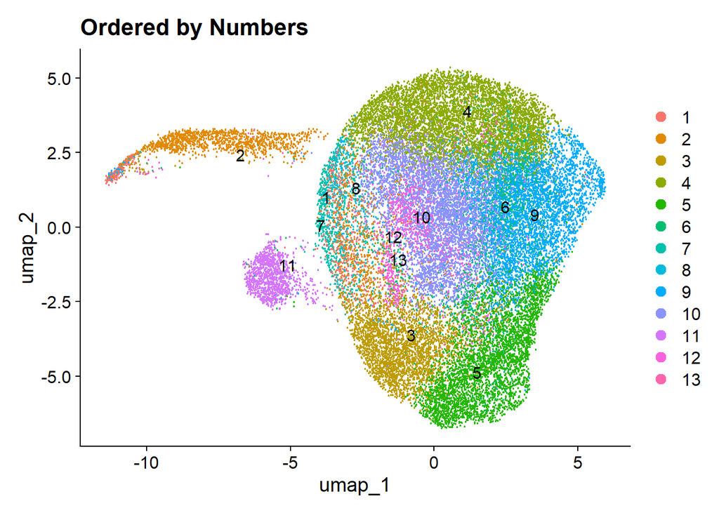

```r
# Plot by Number
Idents(seurat) <- "seurat_clusters"

DimPlot(seurat, reduction = "umap", label = TRUE, repel = TRUE) +
  ggtitle("Ordered by Numbers")
```

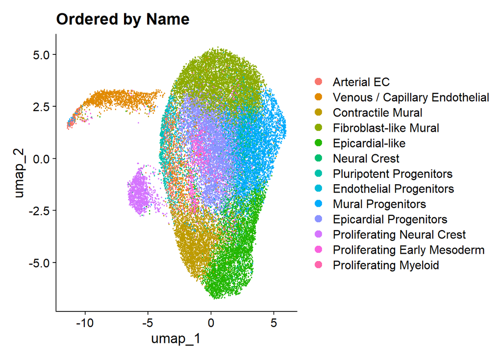

```r
# Plot by Name
Idents(seurat) <- "final_type"

DimPlot(seurat, reduction = "umap", label = FALSE) +
  ggtitle("Ordered by Name")
```

# Analize composition WT vs KO

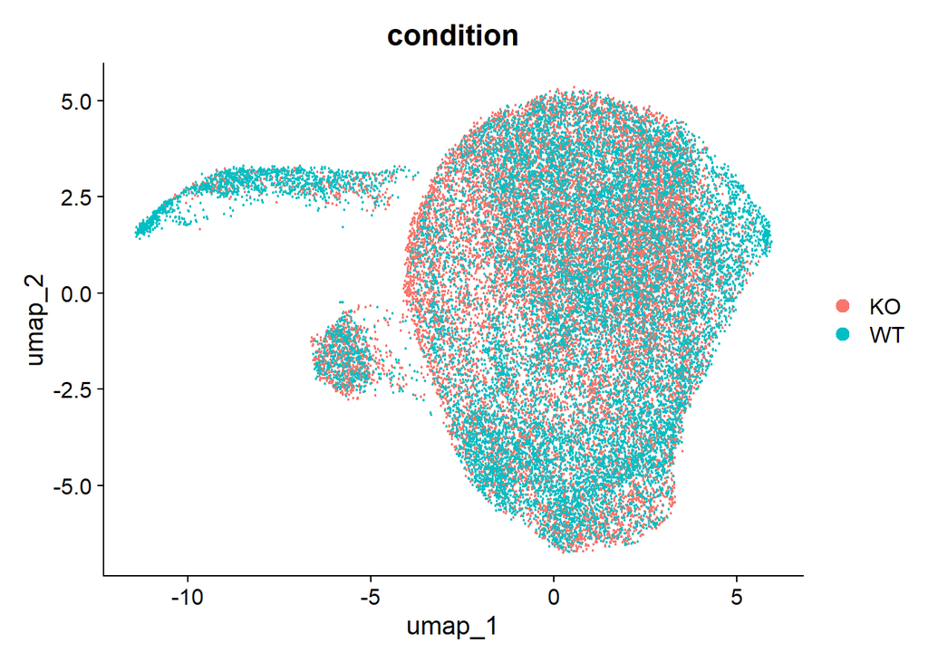

```r
DimPlot(seurat, reduction = "umap", group.by = "condition")
```

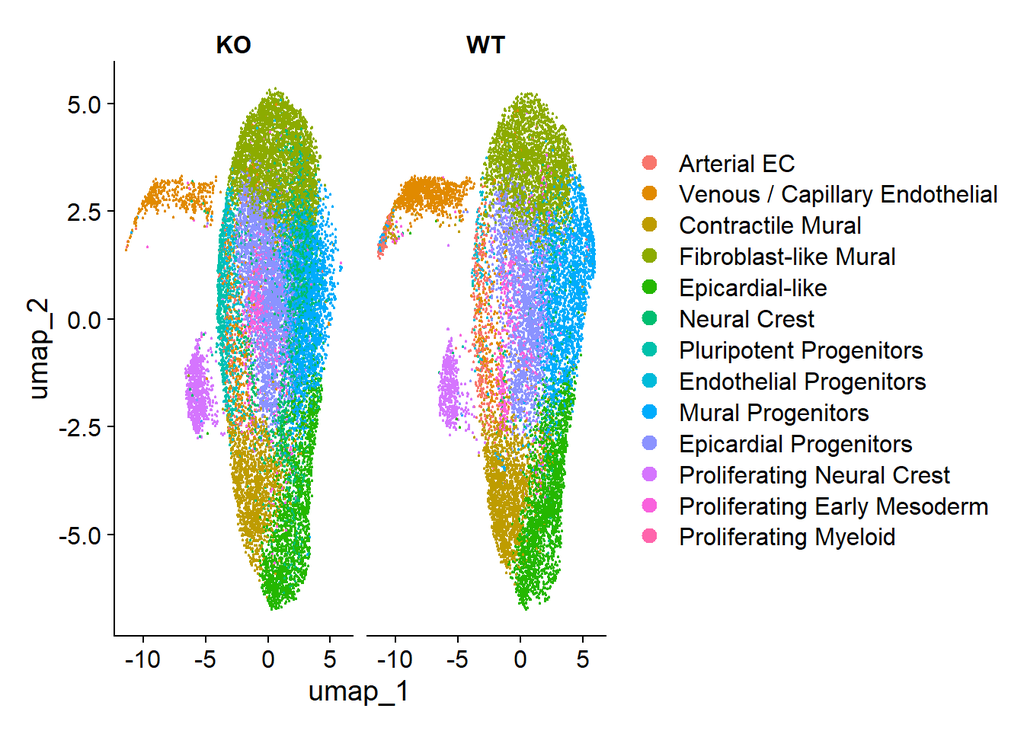

```r
DimPlot(seurat, reduction = "umap", split.by = "condition")
```

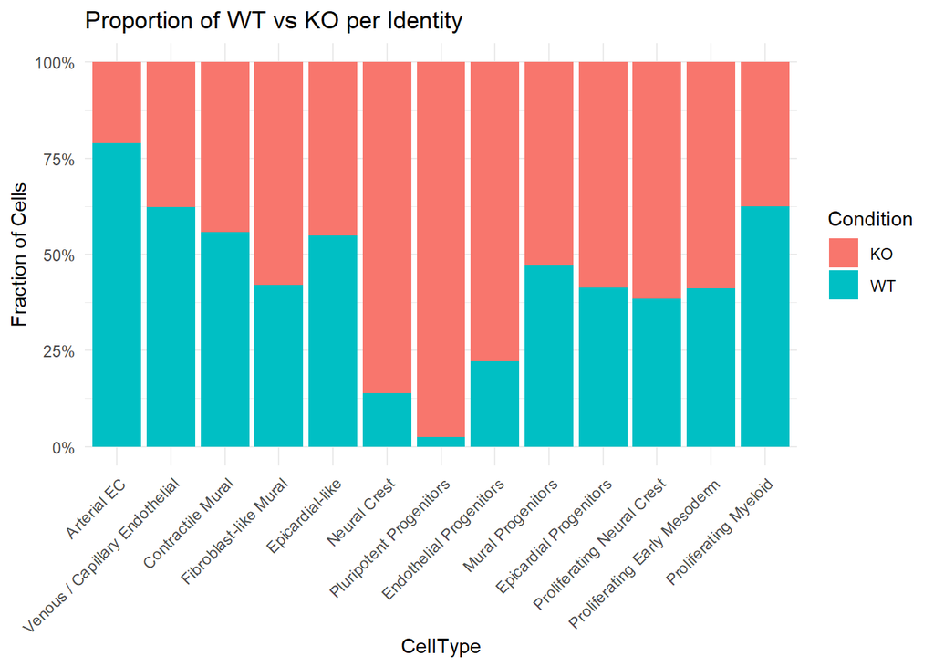

```r
# Use final_type to get biological names instead of numbers
counts <- table(seurat$final_type, seurat$condition)

# Convert to proportions
proportions <- as.data.frame(prop.table(counts, margin = 1))
colnames(proportions) <- c("CellType", "Condition", "Proportion")

# Plot - note that X is now 'CellType' which contains the strings
ggplot(proportions, aes(x = CellType, y = Proportion, fill = Condition)) +
  geom_bar(stat = "identity", position = "stack") +
  theme_minimal() +
  # Rotate labels so they don't overlap
  theme(axis.text.x = element_text(angle = 45, hjust = 1)) +
  labs(y = "Fraction of Cells", title = "Proportion of WT vs KO per Identity") +
  scale_y_continuous(labels = scales::percent)
```

Observation: Pluripotent Cells are more in KO since they struggle to differentiate and remain indeed undifferentiated. Arterial EC are way more in WT since they differentiate more than KO (so less pluripotent).

# Next analysis

## Comparison of cell type compositions between conditions

Based on the following tutorials: https://bioconductor.org/packages/release/bioc/vignettes/miloR/inst/doc/milo_demo.html and https://rawcdn.githack.com/MarioniLab/miloR/7c7f906b94a73e62e36e095ddb3e3567b414144e/vignettes/milo_gastrulation.html#5_Finding_markers_of_DA_populations

Here we use Milo, a method that does not rely on predefined cluster or cell type/state labels. Milo is a tool for analysis of complex single cell datasets generated from replicated multi-condition experiments, which detects changes in composition between conditions. While differential abundance (DA) is commonly quantified in discrete cell clusters, Milo uses partially overlapping neighbourhoods of cells on a KNN graph. Starting from a graph that faithfully recapitulates the biology of the cell population, Milo analysis consists of 3 steps: 1. Sampling of representative neighbourhoods 2. Testing for differential abundance of conditions in all neighbourhoods 3. Accounting for multiple hypothesis testing using a weighted FDR procedure that accounts for the overlap of neighbourhoods

```r
# turning our Seurat object into a SingleCellExperiment object
seurat[["integrated"]] <- as(object = seurat[["integrated"]], Class = "Assay")
sce <- as.SingleCellExperiment(seurat, assay = "integrated")
```

```r
# sample information is stored in colData(sce)$condition
colData(sce)
```

```
## DataFrame with 30536 rows and 13 columns
##                          orig.ident nCount_RNA nFeature_RNA        sample
##                         <character>  <numeric>    <integer>   <character>
## AAACCCAAGGCTCACC-1_7  SeuratProject       8901         2944 B1_17_1_day21
## AAACCCAAGTTGAATG-1_7  SeuratProject       5406         1951 B1_17_1_day21
## AAACCCATCAAATGAG-1_7  SeuratProject      20568         5011 B1_17_1_day21
## AAACCCATCGGAGTGA-1_7  SeuratProject       6836         2316 B1_17_1_day21
## AAACGAACAGAACTTC-1_7  SeuratProject      20081         5028 B1_17_1_day21
## ...                             ...        ...          ...           ...
## TTTGTTGCACGCTATA-1_15 SeuratProject      17641         4547    wt_2_day21
## TTTGTTGCAGACCAGA-1_15 SeuratProject      11255         3256    wt_2_day21
## TTTGTTGTCCGATGTA-1_15 SeuratProject       7023         2007    wt_2_day21
## TTTGTTGTCCGGACTG-1_15 SeuratProject       4920         1915    wt_2_day21
## TTTGTTGTCGTCTAAG-1_15 SeuratProject      11035         3045    wt_2_day21
##                         condition percent.mt    S.Score  G2M.Score       Phase
##                       <character>  <numeric>  <numeric>  <numeric> <character>
## AAACCCAAGGCTCACC-1_7           KO    6.16785 -0.0805073  -0.168785          G1
## AAACCCAAGTTGAATG-1_7           KO    5.14243 -0.1204097  -0.177162          G1
## AAACCCATCAAATGAG-1_7           KO    5.53287 -0.0984064  -0.177371          G1
## AAACCCATCGGAGTGA-1_7           KO    5.32475 -0.0418761  -0.147545          G1
## AAACGAACAGAACTTC-1_7           KO    7.68388  0.1334466   0.564170         G2M
## ...                           ...        ...        ...        ...         ...
## TTTGTTGCACGCTATA-1_15          WT    6.82501  0.4697763  0.0412033           S
## TTTGTTGCAGACCAGA-1_15          WT    7.83652  0.1915987 -0.0317927           S
## TTTGTTGTCCGATGTA-1_15          WT    5.52470 -0.0626866 -0.1119768          G1
## TTTGTTGTCCGGACTG-1_15          WT    6.89024 -0.0353001 -0.0869109          G1
## TTTGTTGTCGTCTAAG-1_15          WT    7.07748 -0.0818474 -0.1180463          G1
##                       integrated_snn_res.0.6 seurat_clusters
##                                     <factor>        <factor>
## AAACCCAAGGCTCACC-1_7                       4              3
## AAACCCAAGTTGAATG-1_7                       2              9
## AAACCCATCAAATGAG-1_7                       3              5
## AAACCCATCGGAGTGA-1_7                       0              4
## AAACGAACAGAACTTC-1_7                       1              10
## ...                                      ...             ...
## TTTGTTGCACGCTATA-1_15                      1              10
## TTTGTTGCAGACCAGA-1_15                      1              10
## TTTGTTGTCCGATGTA-1_15                      1              10
## TTTGTTGTCCGGACTG-1_15                      0              4
## TTTGTTGTCGTCTAAG-1_15                      2              9
##                                   final_type                  ident
##                                     <factor>               <factor>
## AAACCCAAGGCTCACC-1_7  Contractile Mural      Contractile Mural
## AAACCCAAGTTGAATG-1_7  Mural Progenitors      Mural Progenitors
## AAACCCATCAAATGAG-1_7  Epicardial-like        Epicardial-like
## AAACCCATCGGAGTGA-1_7  Fibroblast-like Mural  Fibroblast-like Mural
## AAACGAACAGAACTTC-1_7  Epicardial Progenitors Epicardial Progenitors
## ...                                      ...                    ...
## TTTGTTGCACGCTATA-1_15 Epicardial Progenitors Epicardial Progenitors
## TTTGTTGCAGACCAGA-1_15 Epicardial Progenitors Epicardial Progenitors
## TTTGTTGTCCGATGTA-1_15 Epicardial Progenitors Epicardial Progenitors
## TTTGTTGTCCGGACTG-1_15 Fibroblast-like Mural  Fibroblast-like Mural
## TTTGTTGTCGTCTAAG-1_15 Mural Progenitors      Mural Progenitors
```

```r
# creating a Milo object from our SingleCellExperiment object
milo <- Milo(sce)
reducedDim(milo, "UMAP") <- reducedDim(sce, "UMAP")
reducedDim(milo, "PCA") <- reducedDim(sce, "PCA")
milo
```

```
## class: Milo
## dim: 2000 30536
## metadata(0):
## assays(1): logcounts
## rownames(2000): MGP PTX3 ... HPRT1 NLGN4X
## rowData names(0):
## colnames(30536): AAACCCAAGGCTCACC-1_7 AAACCCAAGTTGAATG-1_7 ...
##   TTTGTTGTCCGGACTG-1_15 TTTGTTGTCGTCTAAG-1_15
## colData names(13): orig.ident nCount_RNA ... final_type ident
## reducedDimNames(2): PCA UMAP
## mainExpName: integrated
## altExpNames(0):
## nhoods dimensions(2): 1 1
## nhoodCounts dimensions(2): 1 1
## nhoodDistances dimension(1): 0
## graph names(0):
## nhoodIndex names(1): 0
## nhoodExpression dimension(2): 1 1
## nhoodReducedDim names(0):
## nhoodGraph names(0):
## nhoodAdjacency dimension(2): 1 1
```

We need to add the KNN graph to the Milo object. This is stored in the graph slot, in igraph format. The miloR package includes functionality to build and store the graph from the PCA dimensions stored in the reducedDim slot. We define the following parameters: d: how many PCs to use k: how many neighbors to consider. k controls neighborhood granularity: smaller k gives smaller, more local neighborhoods (more sensitive, but noisier), while larger k gives smoother, broader neighborhoods (more stable, but may blur nearby states).

```r
milo <- buildGraph(milo, k = 40, d = 15)
```

```
## Constructing kNN graph with k:40
```

We define the neighbourhood of a cell, the index, as the group of cells connected by an edge in the KNN graph to the index cell. We define the following parameters: prop: the proportion of cells to randomly sample to start with (usually 0.1 - 0.2 is sufficient) k: the k to use for KNN refinement (using the same k used for KNN graph building is recommended) d: the number of reduced dimensions to use for KNN refinement (using the same d used for KNN graph building is recommended) refined: indicates whether you want to use the sampling refinement algorithm, or just pick cells at random. The default and recommended way to go is to use refinement.

```r
milo <- makeNhoods(milo, prop = 0.1, k = 40, d=15, refined = TRUE)
```

```
## Checking valid object
```

```
## Running refined sampling with reduced_dim
```

Once we have defined neighbourhoods, it’s good to take a look at how big the neighbourhoods are (i.e. how many cells form each neighbourhood). This affects the power of DA testing. Empirically, it was found that it’s best to have a distribution peaking between 50 and 100. Otherwise you might consider rerunning makeNhoods increasing k and/or prop.

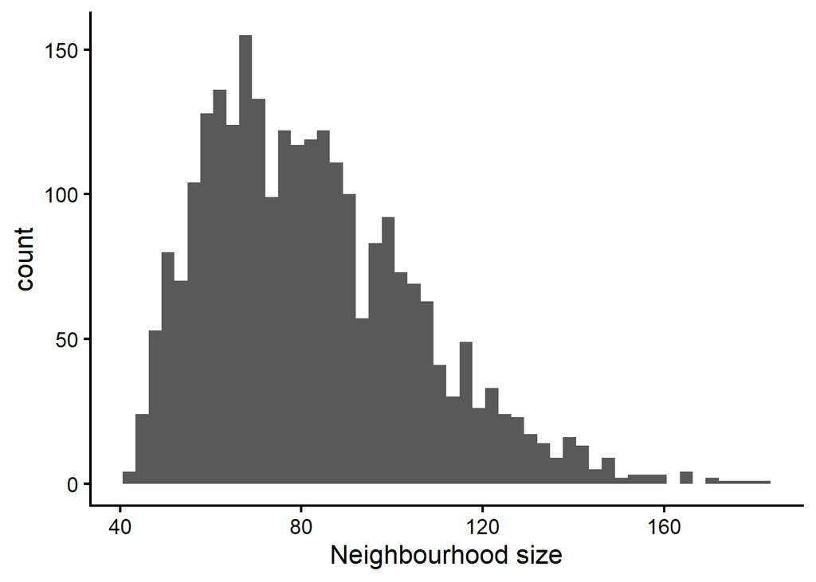

```r
plotNhoodSizeHist(milo)
```

Now we have to count how many cells from each sample are in each neighbourhood. We need to use the cell metadata and specify which column contains the sample information. Each row of the resulting cell count matrix represents a single neighbourhood, while the values indicate the number of cells. This count matrix will be used for DA testing.

```r
milo <- countCells(milo, meta.data = data.frame(colData(milo)), samples="sample")
```

```
## Checking meta.data validity
```

```
## Counting cells in neighbourhoods
```

```r
head(nhoodCounts(milo))
```

```
## 6 x 4 sparse Matrix of class "dgCMatrix"
##   B1_17_1_day21 D2_22_3_day21 wt_4_day21 wt_2_day21
## 1             .             .          2         47
## 2            14            47         24         15
## 3             7             7          6         45
## 4            10            23          1          8
## 5            22            17          3         15
## 6            47            17         10         13
```

Differential abundance testing. We implement hypothesis testing in a generalized linear model (GLM) framework, specifically using the Negative Binomial GLM implementation in edgeR. The design matrix should match samples to a condition of interest. In this case the Condition is the covariate we are going to test for.

```r
dm <- data.frame(colData(milo))[,c("sample", "condition")]
dm <- distinct(dm)
rownames(dm) <- dm$sample

# reorder rownames to match columns of nhoodCounts(milo)
dm <- dm[colnames(nhoodCounts(milo)), , drop=FALSE]

dm$condition <- factor(dm$condition, levels = c("WT", "KO"))

dm
```

```
##                      sample condition
## B1_17_1_day21 B1_17_1_day21        KO
## D2_22_3_day21 D2_22_3_day21        KO
## wt_4_day21       wt_4_day21        WT
## wt_2_day21       wt_2_day21        WT
```

Milo uses an adaptation of the Spatial FDR correction, which accounts for the overlap between neighbourhoods. Specifically, each hypothesis test P-value is weighted by the reciprocal of the kth nearest neighbour distance. To use this statistic we first need to store the distances between nearest neighbors in the Milo object.

```r
milo <- calcNhoodDistance(milo, d=15)
```

```
## 'as(<dgTMatrix>, "dgCMatrix")' is deprecated.
## Use 'as(., "CsparseMatrix")' instead.
## See help("Deprecated") and help("Matrix-deprecated").
```

Now we can calculate a Fold-change and corrected P-value for each neighbourhood, which indicates whether there is significant differential abundance between conditions.

```r
rownames(dm) <- dm$sample
da_results <- testNhoods(milo, design = ~ condition, design.df = dm)
```

```
## Using TMM normalisation
```

```
## Running with model contrasts
```

```
## Performing spatial FDR correction with k-distance weighting
```

```r
da_results %>%
  arrange(- SpatialFDR) %>%
  head()
```

```
##              logFC   logCPM            F    PValue       FDR Nhood SpatialFDR
## 1373  0.0007257448 8.141391 4.451843e-07 0.9994822 0.9994914  1373  0.9994914
## 2098  0.0003853817 8.871705 4.295341e-07 0.9994914 0.9994914  2098  0.9994914
## 1092 -0.0027793918 8.074101 4.623090e-06 0.9983314 0.9991095  1092  0.9990533
## 1465 -0.0022748453 8.716356 5.538535e-06 0.9981736 0.9991095  1465  0.9990533
## 1895  0.0030001694 8.172194 5.960979e-06 0.9981062 0.9991095  1895  0.9990533
## 350  -0.0038572827 8.816800 1.523646e-05 0.9969722 0.9989568   350  0.9988493
```

Visualization. To visualize DA results, we build an abstracted graph of neighbourhoods that we can superimpose on the single-cell embedding.

```
## Adding nhood effect sizes to neighbourhood graph attributes
```

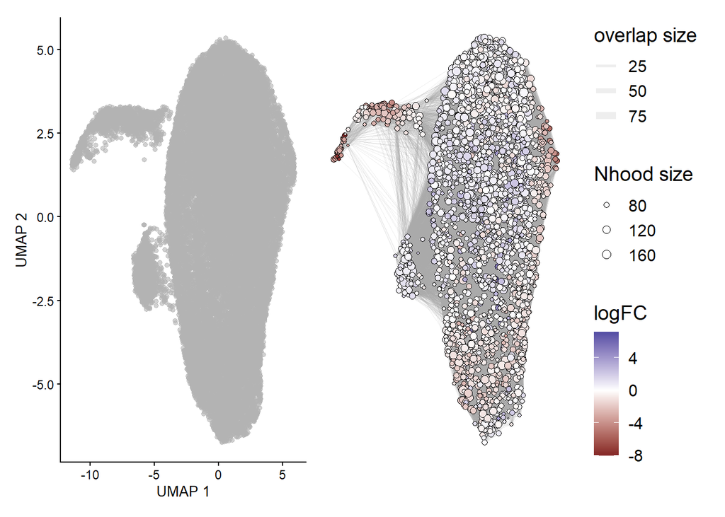

```r
milo <- buildNhoodGraph(milo)

plotUMAP(milo) + plotNhoodGraphDA(milo, da_results, alpha=1) +
  plot_layout(guides="collect")
```

Using this method, we get no significant results. This is completely normal considering the fact that we only have two replicates for each condition. The WT samples were used as a reference. Hence, positive logFC values (blue) indicate neighborhoods enriched in KO and negative logFC values (red) indicate neighborhoods enriched in WT.

Here we visualize whether DA is particularly evident in certain cell types. To do this, we assign a cell type label to each neighbourhood by finding the most abundant cell type within cells in each neighbourhood. We also saves the fraction of cells harbouring the label.

```r
da_results <- annotateNhoods(milo, da_results, coldata_col = "final_type")
head(da_results)
```

```
##         logFC   logCPM           F     PValue       FDR Nhood SpatialFDR
## 1 -7.60243199 8.067291 11.36018024 0.01007694 0.7602852     1  0.7966582
## 2 -0.07616961 9.019615  0.01156166 0.91673292 0.9725445     2  0.9745806
## 3 -1.97831271 8.460574  3.98987923 0.07688912 0.7602852     3  0.7966582
## 4  1.51444748 7.776405  0.92860415 0.36041975 0.7912749     4  0.8189846
## 5  0.99565395 8.308081  0.99129346 0.34545853 0.7862678     5  0.8156087
## 6  1.31733536 8.999390  2.31680634 0.16292690 0.7602852     6  0.7966582
##                       final_type final_type_fraction
## 1                    Arterial EC           0.8367347
## 2              Contractile Mural           0.7700000
## 3 Venous / Capillary Endothelial           1.0000000
## 4                Epicardial-like           0.7619048
## 5          Fibroblast-like Mural           0.9298246
## 6   Proliferating Early Mesoderm           0.9885057
```

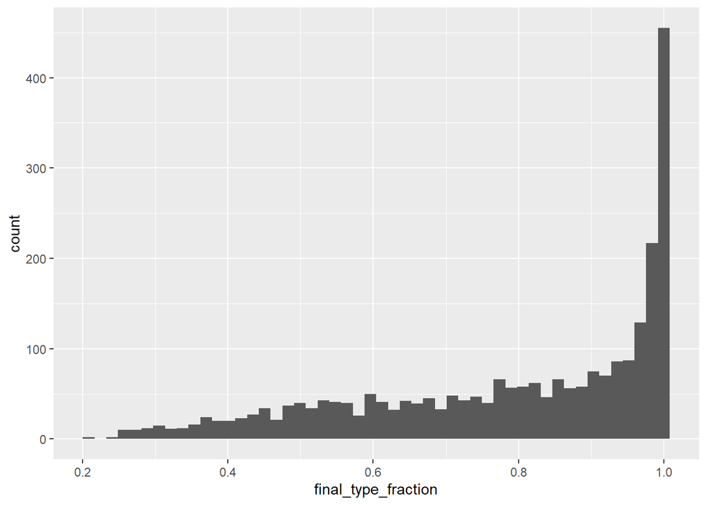

```r
# visualizing the distribution of most abundant cell type fractions
ggplot(da_results, aes(final_type_fraction)) + geom_histogram(bins=50)
```

Most neighborhoods are relatively homogeneous.

```r
# we can define a threshold for final_type_fraction to exclude neighbourhoods that are a mix of cell types
da_results$final_type <- ifelse(da_results$final_type_fraction < 0.7, "Mixed", da_results$final_type)
```

```
## Converting group_by to factor...
```

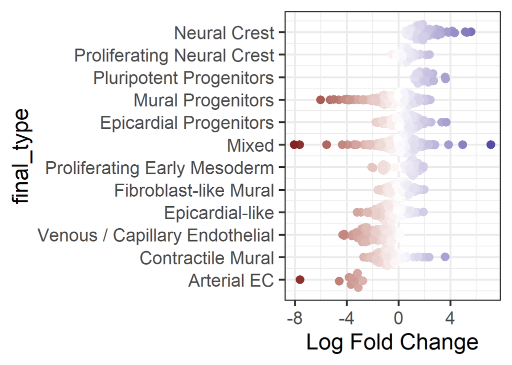

```r
# visualizing the distribution of DA Fold Changes in different cell types
plotDAbeeswarm(da_results, group.by = "final_type", alpha = 1)
```

Again, no significant results. Each dot is a neighborhood, not an entire cell type, so within one annotated cell type, different local regions can behave differently between WT and KO. That is the reason why we might see both positive and negative logFC inside the same broad annotation. This could mean that WT enriches one sub-state, whereas KO enriches another rather than the entire lineage uniformly increasing/decreasing. This distinguishes Milo from cluster-based DA, which investigates if the total number of cells in cluster X changes. Milo investigates change in local regions, so it naturally produces bidirectional effects inside broad labels and fine-grained state-specific DA.

Additional steps? Plot marker gradients across DA regions